# ML для HR процессов

### Исследовательский анализ данных

#### Анализ df_train

```
Анализ df_train_2
interval columns not set, guessing: ['employment_years', 'supervisor_evaluation', 'salary']
```

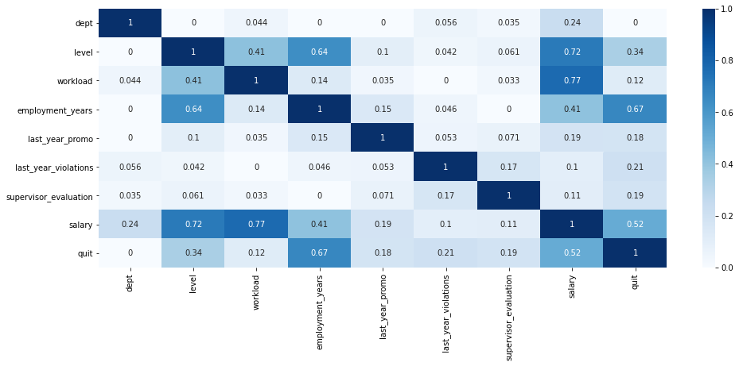

```python
print('Анализ df_train_2')
corr_max(df_train_2)
```

```
Pie диаграммы тренировочной выборки

dept анализ
```

```
count      2587
unique        5
top       sales
freq        805
Name: dept, dtype: object
```

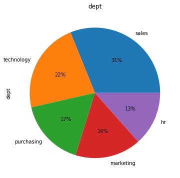

```
level анализ
```

```
count       2587
unique         3
top       middle
freq        1282
Name: level, dtype: object
```

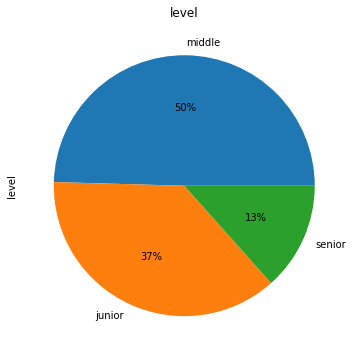

```
workload анализ
```

```
count       2587
unique         3
top       medium
freq        1244
Name: workload, dtype: object
```

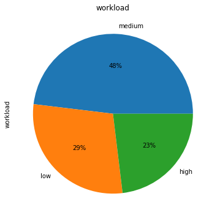

```
last_year_promo анализ
```

```
count     2587
unique       2
top         no
freq      2476
Name: last_year_promo, dtype: object
```

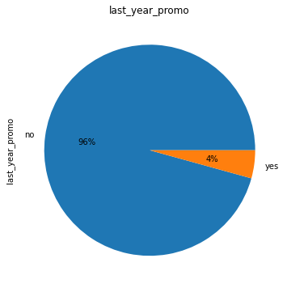

```
last_year_violations анализ
```

```
count     2587
unique       2
top         no
freq      2111
Name: last_year_violations, dtype: object
```

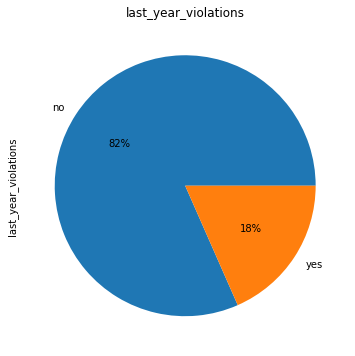

```
quit анализ
```

```
count     2587
unique       2
top         no
freq      1932
Name: quit, dtype: object
```

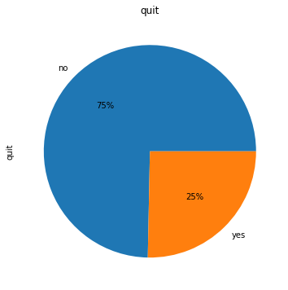

```python
print('Pie диаграммы тренировочной выборки')
print()
barplotter(df_train_2)
```

```
Гистограммы и Box диаграммы тренировочной выборки

employment_years анализ
```

```
count    2587.000000
mean        4.213375
std         2.601105
min         1.000000
25%         2.000000
50%         4.000000
75%         6.000000
max        10.000000
Name: employment_years, dtype: float64
```

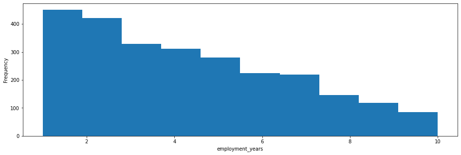

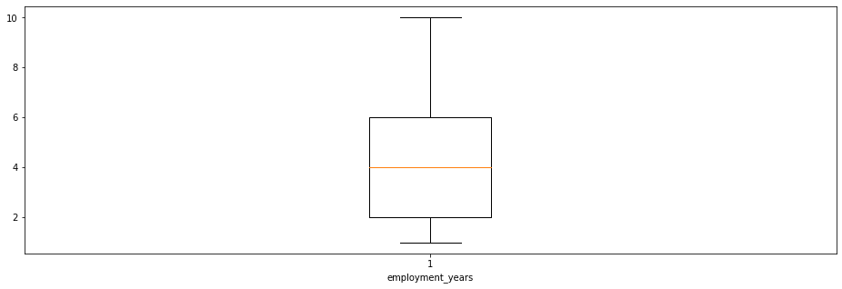

```
supervisor_evaluation анализ
```

```
count    2587.000000
mean        3.367994
std         1.080243
min         1.000000
25%         3.000000
50%         3.000000
75%         4.000000
max         5.000000
Name: supervisor_evaluation, dtype: float64
```

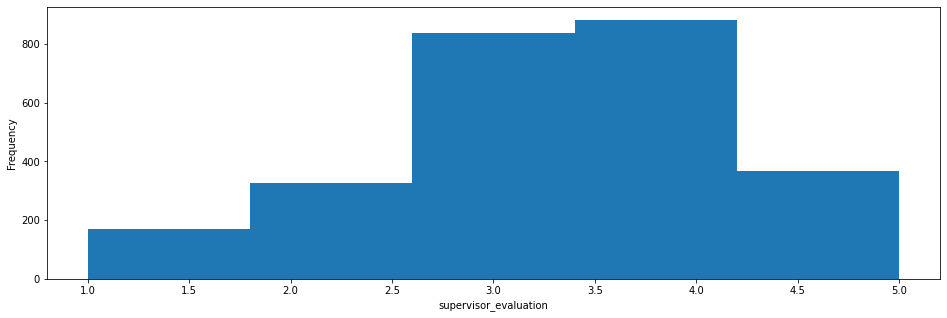

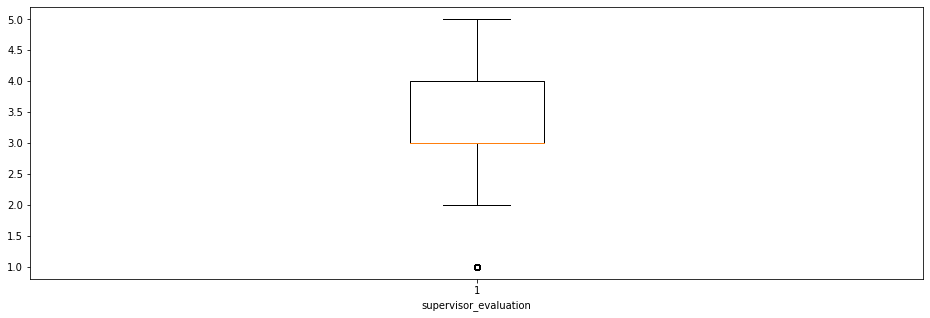

```
salary анализ
```

```
count     2587.000000
mean     37107.692308
std      16267.354906
min      12000.000000
25%      24000.000000
50%      33600.000000
75%      46800.000000
max      96000.000000
Name: salary, dtype: float64
```

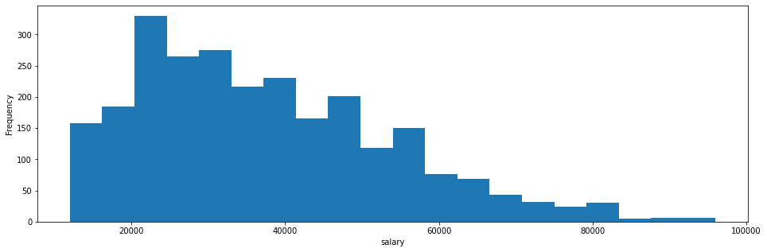

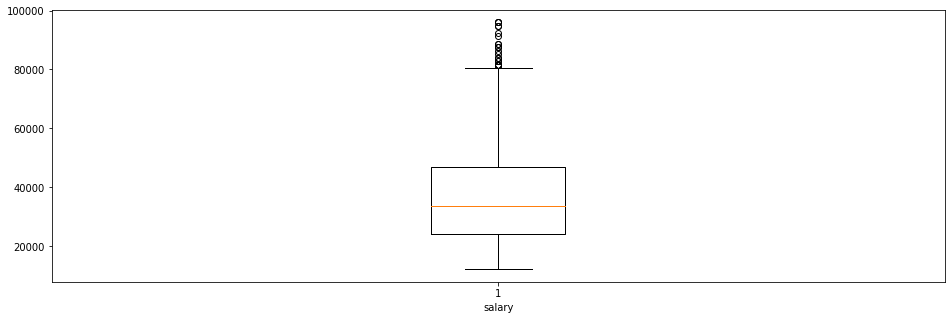

```python
print('Гистограммы и Box диаграммы тренировочной выборки')
print()
histplotter(df_train_2)
```

#### Проанализируем входные параметры в разбивке по таргету (ушедшие vs оставшиеся)

```
Количество оставшихся сотрудников 1932
Количество ушедших сотрудников 655
employment_years анализ ушедших
```

```
count    655.000000
mean       2.161832
std        1.497626
min        1.000000
25%        1.000000
50%        2.000000
75%        3.000000
max       10.000000
Name: employment_years, dtype: float64
```

```
employment_years анализ оставшихся
```

```
count    1932.000000
mean        4.908903
std         2.527730
min         1.000000
25%         3.000000
50%         5.000000
75%         7.000000
max        10.000000
Name: employment_years, dtype: float64
```

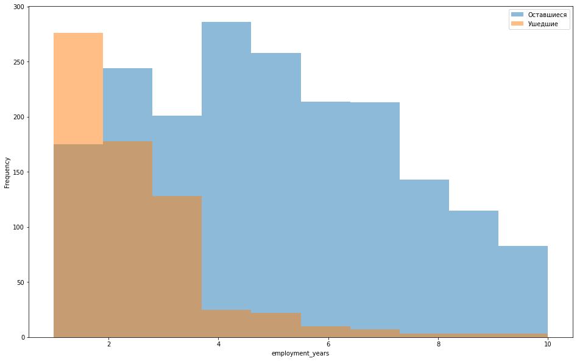

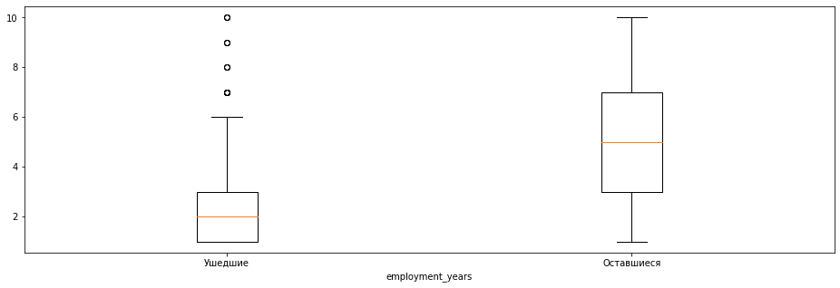

```
supervisor_evaluation анализ ушедших
```

```
count    655.000000
mean       2.958779
std        1.047705
min        1.000000
25%        2.000000
50%        3.000000
75%        4.000000
max        5.000000
Name: supervisor_evaluation, dtype: float64
```

```
supervisor_evaluation анализ оставшихся
```

```
count    1932.000000
mean        3.506729
std         1.055898
min         1.000000
25%         3.000000
50%         4.000000
75%         4.000000
max         5.000000
Name: supervisor_evaluation, dtype: float64
```

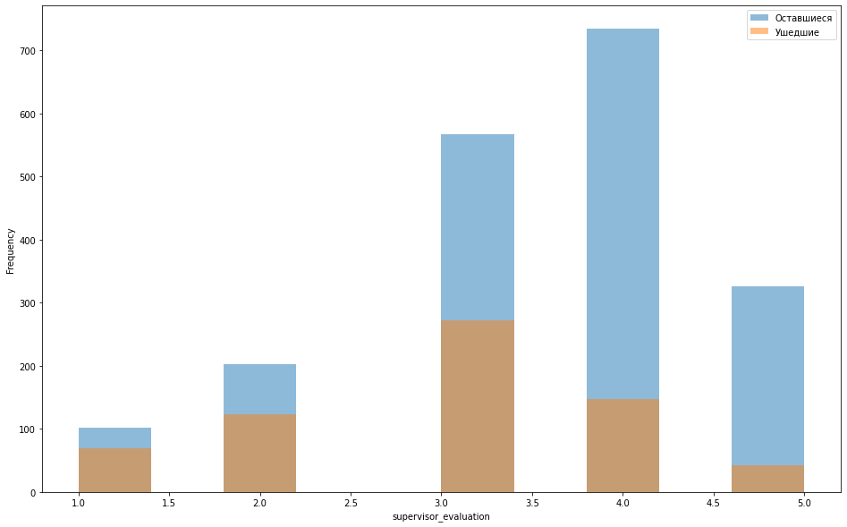

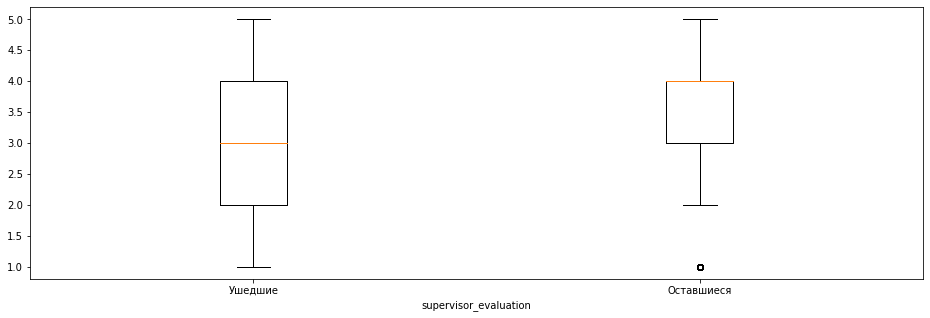

```
salary анализ ушедших
```

```
count      655.000000
mean     25767.938931
std      10484.828614
min      12000.000000
25%      18000.000000
50%      24000.000000
75%      30600.000000
max      79200.000000
Name: salary, dtype: float64
```

```
salary анализ оставшихся
```

```
count     1932.000000
mean     40952.173913
std      16085.739667
min      12000.000000
25%      27600.000000
50%      39000.000000
75%      51600.000000
max      96000.000000
Name: salary, dtype: float64
```

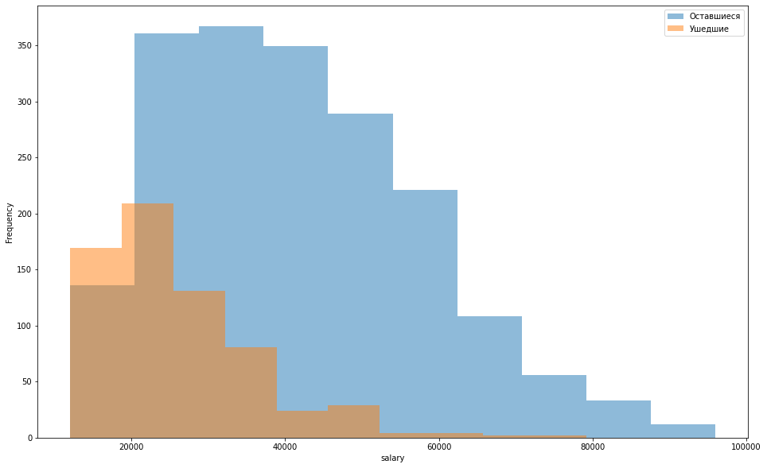

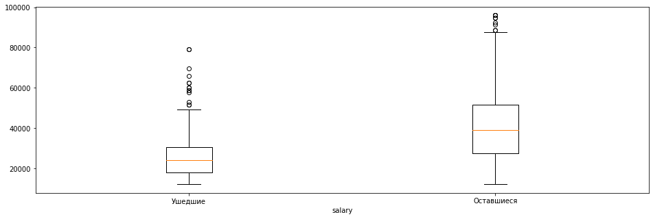

```python
df_train_2_stay = df_train_2[df_train_2['quit'] == 'no']
print('Количество оставшихся сотрудников',len(df_train_2_stay))

df_train_2_leave = df_train_2[df_train_2['quit'] == 'yes']
print('Количество ушедших сотрудников',len(df_train_2_leave))

# Анализ численных входных данных в разбивке по таргету (ушедшие vs оставшиеся)
for column in df_train_2.drop(['quit'], axis = 1).select_dtypes(exclude=[object]).columns:
    print(column, 'анализ ушедших')
    display(df_train_2_leave[column].describe())
    print()
    print(column, 'анализ оставшихся')
    display(df_train_2_stay[column].describe())
    print()
    plt.figure(figsize=(16, 10))
    plt.hist(x = df_train_2_stay[column], alpha = 0.5)
    plt.hist(x = df_train_2_leave[column], alpha = 0.5)
    plt.legend(['Оставшиеся', 'Ушедшие'])
    plt.xlabel(column)
    plt.ylabel('Frequency')
    plt.show()
    plt.figure(figsize=(16, 5))
    plt.boxplot([df_train_2_leave[column], df_train_2_stay[column]], labels = ['Ушедшие', 'Оставшиеся'])
    plt.xlabel(column)
    plt.show()
```

```
dept анализ ушедших
```

```
count       655
unique        5
top       sales
freq        191
Name: dept, dtype: object
```

```
dept анализ оставшихся
```

```
count      1932
unique        5
top       sales
freq        614
Name: dept, dtype: object
```

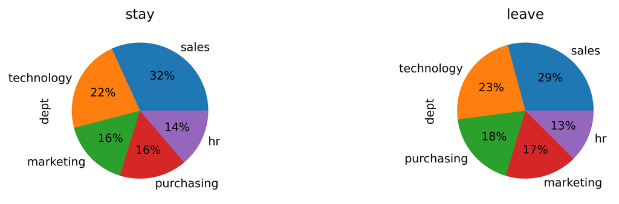

```
level анализ ушедших
```

```
count        655
unique         3
top       junior
freq         537
Name: level, dtype: object
```

```
level анализ оставшихся
```

```
count       1932
unique         3
top       middle
freq        1181
Name: level, dtype: object
```

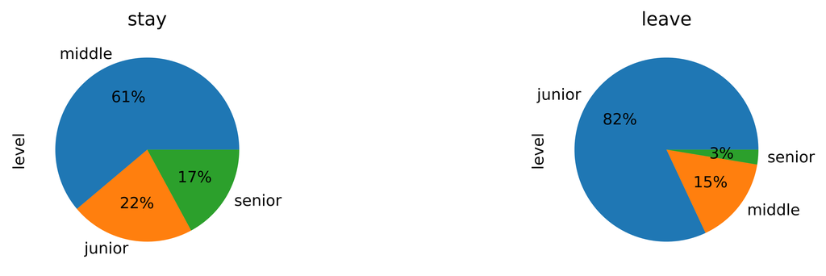

```
workload анализ ушедших
```

```
count     655
unique      3
top       low
freq      291
Name: workload, dtype: object
```

```
workload анализ оставшихся
```

```
count       1932
unique         3
top       medium
freq         989
Name: workload, dtype: object
```

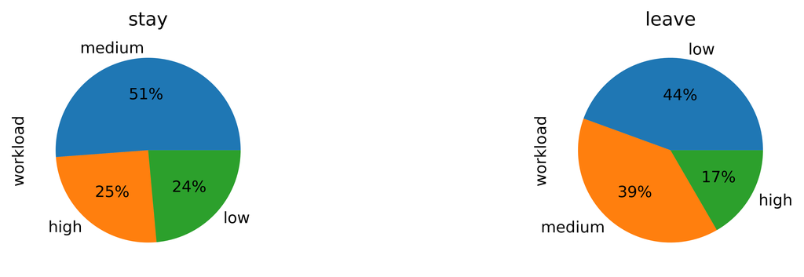

```
last_year_promo анализ ушедших
```

```
count     655
unique      2
top        no
freq      654
Name: last_year_promo, dtype: object
```

```
last_year_promo анализ оставшихся
```

```
count     1932
unique       2
top         no
freq      1822
Name: last_year_promo, dtype: object
```

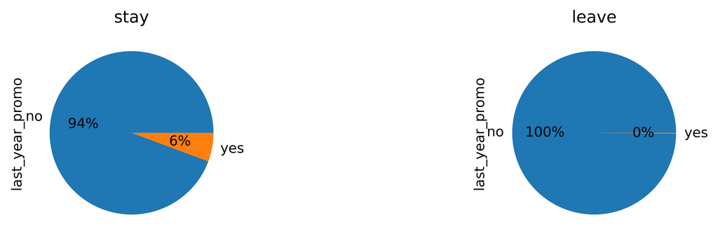

```
last_year_violations анализ ушедших
```

```
count     655
unique      2
top        no
freq      475
Name: last_year_violations, dtype: object
```

```
last_year_violations анализ оставшихся
```

```
count     1932
unique       2
top         no
freq      1636
Name: last_year_violations, dtype: object
```

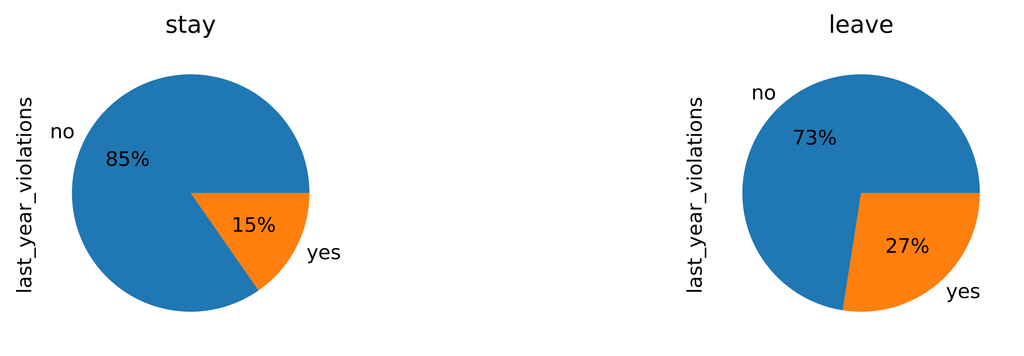

```python
# Анализ категориальных входных данных в разбивке по таргету (ушедшие vs оставшиеся)

for column in df_train_2.drop(['quit'], axis = 1).select_dtypes(include=[object]).columns:
    print(column, 'анализ ушедших')
    display(df_train_2_leave[column].describe())
    print()
    print(column, 'анализ оставшихся')
    display(df_train_2_stay[column].describe())
    print()
    fig = plt.figure(figsize=(18,10), dpi=800)

    ax1 = plt.subplot2grid((2,2),(0,0))
    df_train_2_stay[column].value_counts(dropna=False).plot(kind="pie", autopct='%1.0f%%', figsize=(11, 6))
    plt.title('stay')

    ax1 = plt.subplot2grid((2,2), (0, 1))
    df_train_2_leave[column].value_counts(dropna=False).plot(kind="pie", autopct='%1.0f%%', figsize=(11, 6))
    plt.title('leave')
    plt.show()
```

#### Портрет «уволившегося сотрудника»

В ходе сравнительного анализа выявлено, что в группу риска попадают люди со следующими признаками:

- имеют малый стаж работы (2 год в компании в среднем по сравнению с 5 годами остающихся),
- имеют более низкую оценку от руководителя (3 vs 4),
- имеют более низкую зарплату (24000 vs 39000),
- имеют более низкие грейды (чаще всего джуны),
- совсем не получают повышений.

При этом увольнение не зависит от департамента и нельзя однозначно сказать, что ушедшие нагружены сильнее, чем оставшиеся.

Все выводы достаточно ожидаемы и логичны.

#### Взаимосвязь увольнения и уровня удовлетворенности

```python
#Создаем датафрейм с данным об уровне удовлетворенности и увольнениями
df_y_test_merged = df_y_test.join(df_y_test_2, how = 'inner')

df_y_test_merged_stay = df_y_test_merged[df_y_test_merged['quit'] == 'no']

df_y_test_merged_leave = df_y_test_merged[df_y_test_merged['quit'] == 'yes']
```

```
job_satisfaction_rate анализ ушедших
```

```
count    564.000000
mean       0.387713
std        0.185784
min        0.040000
25%        0.240000
50%        0.370000
75%        0.492500
max        0.970000
Name: job_satisfaction_rate, dtype: float64
```

```
job_satisfaction_rate анализ оставшихся
```

```
count    1436.000000
mean        0.612040
std         0.199367
min         0.030000
25%         0.500000
50%         0.660000
75%         0.760000
max         1.000000
Name: job_satisfaction_rate, dtype: float64
```

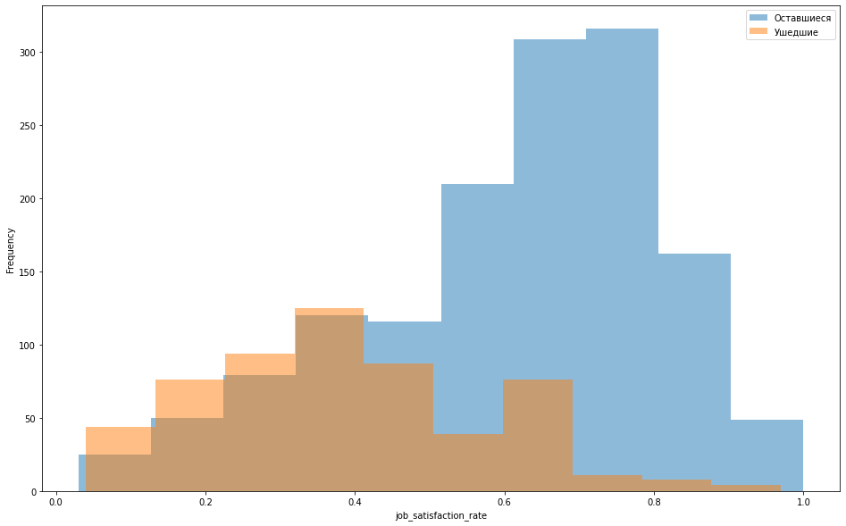

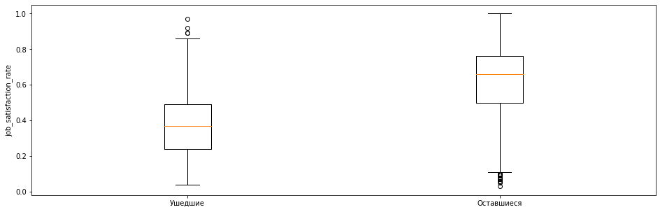

```python
column = 'job_satisfaction_rate'
print(column, 'анализ ушедших')
display(df_y_test_merged_leave[column].describe())
print()
print(column, 'анализ оставшихся')
display(df_y_test_merged_stay[column].describe())
print()

plt.figure(figsize=(16, 10))
plt.hist(x = df_y_test_merged_stay[column], alpha = 0.5)
plt.hist(x = df_y_test_merged_leave[column], alpha = 0.5)
plt.legend(['Оставшиеся', 'Ушедшие'])
plt.xlabel(column)
plt.ylabel('Frequency')
plt.show()
plt.figure(figsize=(16, 5))
plt.boxplot([df_y_test_merged_leave[column], df_y_test_merged_stay[column]], labels = ['Ушедшие', 'Оставшиеся'])
plt.ylabel(column)
plt.show()
```

#### Выводы о взаимосвязи увольнений и уровне удовлетворенности

Наблюдается логичная сильная взаимосвязь уровня удовлетворенности и увольнением - уволившиеся люди в среднем гораздо менее удовлетворенные (медиана уровня удовлетворенности 0.37 у уволившихся против 0.66 у оставшихся).

### Добавление нового входного признака

```python
display(df_train_2.sample(5))
```

[output not shown]

2587 rows × 9 columns

```python
# Добавляем предсказанный первой моделью уровень удовлетворенности в качестве входного параметра для второй задачи

buf = randomized_search.best_estimator_.named_steps['preprocessor'].transform(df_train_2.drop(['quit'], axis = 1))
df_train_2['job_satisfaction_rate'] = best_model.predict(buf)
display(df_train_2.sample(5))
```

[output not shown]

2587 rows × 10 columns

### Подготовка данных

```python
RANDOM_STATE = 42

X_train_2 = df_train_2.drop('quit', axis = 1)
y_train_2 = df_train_2['quit']

y_test_2 = df_x_test_2.join(df_y_test_merged, how = 'left')['quit']
X_test_2 = df_x_test_2.join(df_y_test_merged, how = 'left').drop(['quit'], axis = 1)

# Cоздаём списки с названиями признаков
num_columns_2 = ['employment_years', 'supervisor_evaluation', 'salary', 'job_satisfaction_rate']
ohe_columns_2 = ['dept', 'last_year_promo', 'last_year_violations']
ord_columns_2 = ['level', 'workload']

# Cоздаём пайплайн для подготовки признаков из списка ohe_columns: заполнение пропусков и OHE-кодирование
# SimpleImputer + OHE
ohe_pipe_2 = Pipeline(
    [('simpleImputer_ohe', SimpleImputer(missing_values=np.nan, strategy='most_frequent')),
     ('ohe', OneHotEncoder(drop='first', handle_unknown='ignore', sparse_output=False))
    ]
    )

# Cоздаём пайплайн для подготовки признаков из списка ord_columns: заполнение пропусков и Ordinal-кодирование
# SimpleImputer + OE
ord_pipe_2 = Pipeline(
    [('simpleImputer_before_ord', SimpleImputer(missing_values=np.nan, strategy='most_frequent')),
     ('ord',  OrdinalEncoder(
                categories=[
                    ['junior', 'middle', 'senior'],
                    ['low', 'medium', 'high']
                ],
                handle_unknown='use_encoded_value', unknown_value=-1 #unknown_value=np.nan
            )
        ),
     ('simpleImputer_after_ord', SimpleImputer(missing_values=np.nan, strategy='most_frequent'))
    ]
)

# Cоздаём общий пайплайн для подготовки данных
data_preprocessor_2 = ColumnTransformer(
    [('ohe', ohe_pipe_2, ohe_columns_2),
     ('ord', ord_pipe_2, ord_columns_2),
     ('num', MinMaxScaler(), num_columns_2)
    ],
    remainder='passthrough'
)
```

#### Выводы по подготовке данных

Создан пайплайн подготовки данных, при создании учтено содержимое входных данных: численное, категориальные и категориальный ранговые, использованы OneHotEncoder и OrdinalEncoder соответственно.

### Обучение модели 2

```python
# Cоздаём итоговый пайплайн: подготовка данных и модель 2
pipe_final_2 = Pipeline([
    ('preprocessor', data_preprocessor_2),
    ('models', DecisionTreeClassifier(random_state=RANDOM_STATE))
])

# Cетка параметров для перебора
param_grid_2 = [
    # Cловарь для модели DecisionTreeClassifier()
    {
        'models': [DecisionTreeClassifier(random_state=RANDOM_STATE)],
        'models__max_depth': range(4,30),
        'models__max_features': range(2,15),
        'preprocessor__num': [StandardScaler(), MinMaxScaler(), 'passthrough']
    },

    # Cловарь для модели KNeighborsClassifier()
    {
        'models': [KNeighborsClassifier()],
        'models__n_neighbors': range(2,10),
        'preprocessor__num': [StandardScaler(), MinMaxScaler(), 'passthrough']
    },

    # Cловарь для модели SVC()
    {
        'models': [SVC(
            probability=True,
            random_state=RANDOM_STATE
        )],
        'models__C': range(1,10),
        'preprocessor__num': [StandardScaler(), MinMaxScaler(), 'passthrough']
    }
]

randomized_search_2 = RandomizedSearchCV(
    pipe_final_2,
    param_grid_2,
    cv=5,
    n_iter = 100,
    scoring='roc_auc',
    random_state=RANDOM_STATE,
    n_jobs=-1
)

randomized_search_2.fit(X_train_2, y_train_2)

print('Лучшая модель и её параметры:\n\n', randomized_search_2.best_estimator_)

print()
print ('Значение ROC_AUC метрики лучшей модели 2 на тренировочной выборке:', randomized_search_2.best_score_)

# Лучшая модель
best_model_2 = randomized_search_2.best_estimator_.named_steps['models']

print('Значение ROC_AUC метрики лучшей модели 2 на тестовой выборке:', roc_auc_score(y_test_2, randomized_search_2.best_estimator_.predict_proba(X_test_2)[:, 1]))
```

```
Лучшая модель и её параметры:

 Pipeline(steps=[('preprocessor',
                 ColumnTransformer(remainder='passthrough',
                                   transformers=[('ohe',
                                                  Pipeline(steps=[('simpleImputer_ohe',
                                                                   SimpleImputer(strategy='most_frequent')),
                                                                  ('ohe',
                                                                   OneHotEncoder(drop='first',
                                                                                 handle_unknown='ignore',
                                                                                 sparse_output=False))]),
                                                  ['dept', 'last_year_promo',
                                                   'last_year_violations']),
                                                 ('ord',
                                                  Pipeline(steps=[('simpleImputer_befor...
                                                                                              ['low',
                                                                                               'medium',
                                                                                               'high']],
                                                                                  handle_unknown='use_encoded_value',
                                                                                  unknown_value=-1)),
                                                                  ('simpleImputer_after_ord',
                                                                   SimpleImputer(strategy='most_frequent'))]),
                                                  ['level', 'workload']),
                                                 ('num', MinMaxScaler(),
                                                  ['employment_years',
                                                   'supervisor_evaluation',
                                                   'salary',
                                                   'job_satisfaction_rate'])])),
                ('models',
                 DecisionTreeClassifier(max_depth=4, max_features=12,
                                        random_state=42))])

Значение ROC_AUC метрики лучшей модели 2 на тренировочной выборке: 0.9019335846895314
Значение ROC_AUC метрики лучшей модели 2 на тестовой выборке: 0.9184285431602661
```

```
Found unknown categories in columns [0] during transform. These unknown categories will be encoded as all zeros
```

```python
# Результаты оптимизации модели 2
cv_results_2 = pd.DataFrame(randomized_search_2.cv_results_)
cv_results_2.sample(5)
```

|  | mean_fit_time | std_fit_time | mean_score_time | std_score_time | param_preprocessor__num | param_models__max_features | param_models__max_depth | param_models | param_models__C | param_models__n_neighbors | params | split0_test_score | split1_test_score | split2_test_score | split3_test_score | split4_test_score | mean_test_score | std_test_score | rank_test_score |
| --- | --- | --- | --- | --- | --- | --- | --- | --- | --- | --- | --- | --- | --- | --- | --- | --- | --- | --- | --- |
| 24 | 0.031922 | 0.003233 | 0.014184 | 0.002476 | StandardScaler() | 14 | 26 | DecisionTreeClassifier(random_state=42) | NaN | NaN | {'preprocessor__num': StandardScaler(), 'model... | 0.712360 | 0.760045 | 0.787852 | 0.771526 | 0.786754 | 0.763707 | 0.027659 | 79 |
| 56 | 0.025052 | 0.000840 | 0.011595 | 0.000250 | MinMaxScaler() | 12 | 5 | DecisionTreeClassifier(random_state=42) | NaN | NaN | {'preprocessor__num': MinMaxScaler(), 'models_... | 0.894787 | 0.890516 | 0.904452 | 0.888858 | 0.875509 | 0.890824 | 0.009380 | 10 |
| 13 | 0.023828 | 0.000794 | 0.010551 | 0.001375 | passthrough | 13 | 15 | DecisionTreeClassifier(random_state=42) | NaN | NaN | {'preprocessor__num': 'passthrough', 'models__... | 0.715664 | 0.764227 | 0.789740 | 0.770607 | 0.800973 | 0.768242 | 0.029393 | 56 |
| 67 | 0.027412 | 0.000560 | 0.011950 | 0.000405 | StandardScaler() | 12 | 12 | DecisionTreeClassifier(random_state=42) | NaN | NaN | {'preprocessor__num': StandardScaler(), 'model... | 0.802917 | 0.785411 | 0.805640 | 0.787911 | 0.803870 | 0.797150 | 0.008645 | 36 |
| 4 | 0.026652 | 0.001473 | 0.011835 | 0.000209 | MinMaxScaler() | 7 | 26 | DecisionTreeClassifier(random_state=42) | NaN | NaN | {'preprocessor__num': MinMaxScaler(), 'models_... | 0.686461 | 0.768892 | 0.799885 | 0.799519 | 0.799144 | 0.770780 | 0.043797 | 52 |

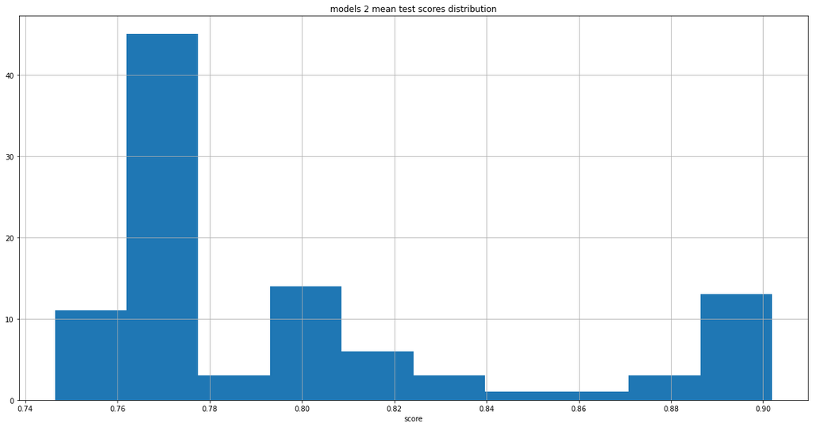

```python
# Выводим mean_test_score

plt.figure(figsize = (20,10))
model_list_2 = list(cv_results_2['params'])
(cv_results_2['mean_test_score']).hist()
plt.xlabel('score')
plt.title('models 2 mean test scores distribution')
```

```
Found unknown categories in columns [0] during transform. These unknown categories will be encoded as all zeros
```

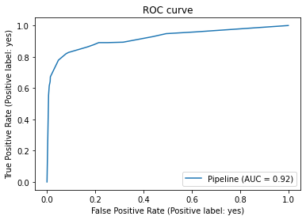

```python
# Строим ROC Curve график для лучшей модели 2 на тестовых данных

RocCurveDisplay.from_estimator(randomized_search_2.best_estimator_, X_test_2, y_test_2)
plt.title('ROC curve');
```

#### Интерпретация модели 2

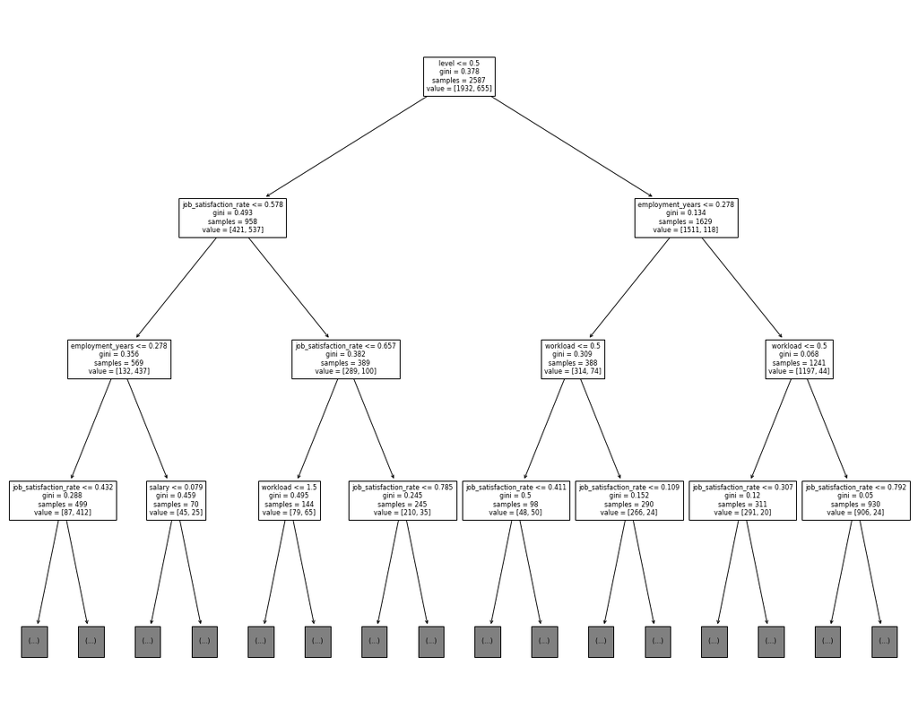

```python
# Строим интерпретацию DecisionTreeClassifier

feature_name_list_2 = randomized_search_2.best_estimator_.named_steps['preprocessor'].transformers_[0][1]['ohe'].get_feature_names_out(ohe_columns_2).tolist() + ord_columns_2 + num_columns_2
plt.figure(figsize=(20,16))
plot_tree(best_model_2,fontsize=8, feature_names = feature_name_list_2, max_depth = 3);
```

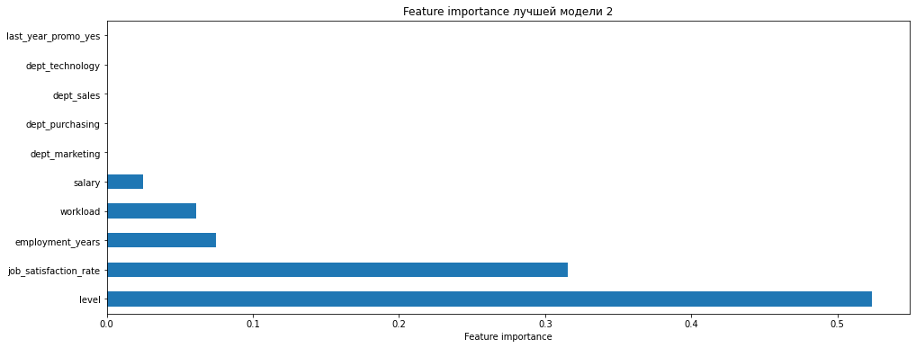

```python
# Feature importance лучшей модели 2

plt.figure(figsize = (16,6))
(pd.Series(best_model_2.feature_importances_, index=feature_name_list_2)
   .nlargest(10)
   .plot(kind='barh'))
plt.title('Feature importance лучшей модели 2')
plt.xlabel('Feature importance');
```

#### Выводы по обучению моделей 2

Модель DecisionTreeClassifier с параметрами max_depth=4, max_features=12 продемонстрировала лучшую метрику в ходе оптимизации (roc_auc_score = 0.9 на тренировочной выборке и roc_auc_score = 0.92 на тестовой выборке), что лучше критерия успеха (0.91).

При этом структура дерева решений и важность признаков в нем выглядит логичной и полностью согласуется с результатами корреляционного анализа и "портретом увольняющегося сотрудника":

- малый стаж работы
- неудовлетворенность работой
- низкая зарплата
- низкий грейд
- низкая загрузка

# Выводы

В рамках проекта было решено 2 задачи от компании «Работа с заботой», которая помогает бизнесу оптимизировать управление персоналом.

В рамках решения **Задачи №1** (Предсказание уровня удовлетворенности сотрудника) были пройдены следующие этапы:

1. Получены, предобработаны и исследованы данные по сотрудникам

Датасеты содержали:

- данные об уровне
- зарплате
- стаже
- нарушениях
- повышениях
- уровне
- оценке

Удалось устранить ошибки в данных и провести исследовательский и корреляционный анализы данных.

2. Построены и использованы пайплайны для подготовки численных и категориальных данных и поиска лучшей модели предсказания уровня удовлетворенности сотрудника

Выбор производился между LinearRegression, Ridge и DecisionTreeRegressor у каждой модели был задан диапазон изменения гиперпараметров для оптимизации.

Модель DecisionTreeRegressor с параметрами max_depth=26, max_features=9 и функцией масштабирования MinMaxScaler продемонстрировала лучшую метрику в ходе оптимизации (SMAPE = 15.6 на тренировочной выборке) и на тестовой выборке выдала значение SMAPE = 16.35, что хуже критерия успеха (SMAPE <= 15). SMAPE - «симметричное среднее абсолютное процентное отклонение».

3. Проведена интерпретация лучшей модели Интерпретация модели показала, что структура дерева решений и важность признаков в нем выглядит логичной и полностью согласуется с результатами корреляционного анализа. Самыми важными признаками для удовлетворенности оказались:
- оценка руководителя
- стаж работы
- нарушения в прошлом году

В рамках решения **Задачи №2** (Предсказание увольнения сотрудников) были пройдены следующие этапы:

1. Данные пополнились новым целевым признаком (Увольнение) и были проведены предобработка, исследовательский и корреляционный анализ.
2. Был составлен "Портрет увольняющегося сотрудника". В ходе сравнительного анализа выявлено, что в группу риска попадают люди со следующими признаками:
- имеют малый стаж работы (2 года в компании в среднем по сравнению с 5 годами остающихся),
- имеют более низкую оценку от руководителя (3 vs 4),
- имеют более низкую зарплату (24000 vs 39000),
- имеют более низкие грейды (чаще всего джуны),
- совсем не получают повышений.

При этом увольнение не зависит от департамента и нельзя однозначно сказать, что ушедшие нагружены сильнее, чем оставшиеся.

Все выводы достаточно ожидаемы и логичны.

3. Проверена и выявлена взаимосвязь уровня удовлетворенности и увольнением сотрудника.
4. Построены и использованы пайплайны для подготовки численных и категориальных данных и поиска лучшей модели предсказания увольнения сотрудника

Модель DecisionTreeClassifier с параметрами max_depth=4, max_features=12 продемонстрировала лучшую метрику в ходе оптимизации (roc_auc_score = 0.9 на тренировочной выборке и roc_auc_score = 0.92 на тестовой выборке), что лучше критерия успеха (0.91 на тестовой выборке).

5. Проведена интерпретация лучшей модели

Интерпретация модели показала, что структура дерева решений и важность признаков в нем выглядит логичной и полностью согласуется с результатами корреляционного анализа и "портретом увольняющегося сотрудника". Самыми решающими признаками для увольнения оказались:

- малый стаж работы
- неудовлетворенность работой
- низкая зарплата
- низкий грейд

**Рекомендации для бизнеса**

1. Чаще всего увольняются новички с низкой зарплатой и низким грейдом:
- для сокращения текучки необходимо уделять им больше времени и лучше подойти к онбордингу и наладить институт наставничества
- также можно рассмотреть вариант найма более высокогрейдовых сотрудников с более высокой зарплатой, поскольку они менее склонны к увольнениям
2. Поскольку низкая удовлетворенность работой также один из ключевых факторов для увольнения, необходимо повышать этот параметр.

Наибольшее влияние на него оказывает оценка от руководителя. Условием хороших оценок традиционно выступают большой объем и сложность проделанной работы и выполнение и превышение ожиданий руководителя. Повышения уровня оценок можно добиться следующими способами:

- более тщательным наймом талантливых и мотивированных сотрудников
- лучшей синхронизацией понимания задач, процессов и ожиданий между руководителем и сотрудником